# Project: Movies Data Analysis

- Introduction
- Data Wrangling
- Exploratory Data Analysis
- Conclusions

## Introduction

> In this project we will analyze the data associated with the valuation of 10,000 collected films associated mainly with the ratings of the users and the income generated. Some columns, like 'cast', 'genres' and 'production_companies', contain multiple values separated by '|'

> The questions that I am trying to explore are:
> 1. What is the most frequent genres of movie in the 21st century?
> 2. How is the comparison in revenue and votes average of those films that had the highest budget in the last 10 years?
> 3. Which actors participated in more films in each of the genres?

```python
# Import packages that we will use throughout the data analysis
import pandas as pd
import numpy as np
import matplotlib.pyplot as plt
import seaborn as sns
%matplotlib inline
```

## Data Wrangling

> **Tip**: In this section of the report, you will load in the data, check for cleanliness, and then trim and clean your dataset for analysis. Make sure that you document your steps carefully and justify your cleaning decisions.

### General Properties

```python
# Data Loading to a dataframe
df= pd.read_csv("tmdb-movies.csv")
df.head(2)
```

|  | id | imdb_id | popularity | budget | revenue | original_title | cast | homepage | director | tagline | ... | overview | runtime | genres | production_companies | release_date | vote_count | vote_average | release_year | budget_adj | revenue_adj |
| --- | --- | --- | --- | --- | --- | --- | --- | --- | --- | --- | --- | --- | --- | --- | --- | --- | --- | --- | --- | --- | --- |
| 0 | 135397 | tt0369610 | 32.985763 | 150000000 | 1513528810 | Jurassic World | Chris Pratt\|Bryce Dallas Howard\|Irrfan Khan\|Vi... | http://www.jurassicworld.com/ | Colin Trevorrow | The park is open. | ... | Twenty-two years after the events of Jurassic ... | 124 | Action\|Adventure\|Science Fiction\|Thriller | Universal Studios\|Amblin Entertainment\|Legenda... | 6/9/15 | 5562 | 6.5 | 2015 | 1.379999e+08 | 1.392446e+09 |
| 1 | 76341 | tt1392190 | 28.419936 | 150000000 | 378436354 | Mad Max: Fury Road | Tom Hardy\|Charlize Theron\|Hugh Keays-Byrne\|Nic... | http://www.madmaxmovie.com/ | George Miller | What a Lovely Day. | ... | An apocalyptic story set in the furthest reach... | 120 | Action\|Adventure\|Science Fiction\|Thriller | Village Roadshow Pictures\|Kennedy Miller Produ... | 5/13/15 | 6185 | 7.1 | 2015 | 1.379999e+08 | 3.481613e+08 |

2 rows × 21 columns

```python
#number of samples in each dataset
#number of columns in each dataset
print("Number of samples: {} rows".format(df.shape[0]))
print("Number of columns: {}".format(df.shape[1]))
```

```
Number of samples: 10866 rows
Number of columns: 21
```

```python
df.info()
```

```
<class 'pandas.core.frame.DataFrame'>
RangeIndex: 10866 entries, 0 to 10865
Data columns (total 21 columns):
 #   Column                Non-Null Count  Dtype
---  ------                --------------  -----
 0   id                    10866 non-null  int64
 1   imdb_id               10856 non-null  object
 2   popularity            10866 non-null  float64
 3   budget                10866 non-null  int64
 4   revenue               10866 non-null  int64
 5   original_title        10866 non-null  object
 6   cast                  10790 non-null  object
 7   homepage              2936 non-null   object
 8   director              10822 non-null  object
 9   tagline               8042 non-null   object
 10  keywords              9373 non-null   object
 11  overview              10862 non-null  object
 12  runtime               10866 non-null  int64
 13  genres                10843 non-null  object
 14  production_companies  9836 non-null   object
 15  release_date          10866 non-null  object
 16  vote_count            10866 non-null  int64
 17  vote_average          10866 non-null  float64
 18  release_year          10866 non-null  int64
 19  budget_adj            10866 non-null  float64
 20  revenue_adj           10866 non-null  float64
dtypes: float64(4), int64(6), object(11)
memory usage: 1.7+ MB
```

### Data Cleaning (NaN Values, Format, Duplicated values)

> In this stage we will carry out the following steps to guarantee the quality of the information that will be useful in the analysis:
> 1. Review duplicate rows
> 2. Review null values
> 3. Review the format of the columns
> 4. Eliminate the columns that will not be useful in the analysis to be carried out

#### First Step: Identify Duplicates

```python
#By the name of the column "ID", I intuit that it is the key of the dataframe,
#I will check if there are duplicates in the data, emphasizing the column "ID"
print("Exists :",str(df.duplicated().sum())," row(s) duplicated")

#to identify the values that contain the duplicate row and evaluate if it is convenient to keep only one row

df[df.duplicated(keep=False)]
```

```
Exists : 1  row(s) duplicated
```

|  | id | imdb_id | popularity | budget | revenue | original_title | cast | homepage | director | tagline | ... | overview | runtime | genres | production_companies | release_date | vote_count | vote_average | release_year | budget_adj | revenue_adj |
| --- | --- | --- | --- | --- | --- | --- | --- | --- | --- | --- | --- | --- | --- | --- | --- | --- | --- | --- | --- | --- | --- |
| 2089 | 42194 | tt0411951 | 0.59643 | 30000000 | 967000 | TEKKEN | Jon Foo\|Kelly Overton\|Cary-Hiroyuki Tagawa\|Ian... | NaN | Dwight H. Little | Survival is no game | ... | In the year of 2039, after World Wars destroy ... | 92 | Crime\|Drama\|Action\|Thriller\|Science Fiction | Namco\|Light Song Films | 3/20/10 | 110 | 5.0 | 2010 | 30000000.0 | 967000.0 |
| 2090 | 42194 | tt0411951 | 0.59643 | 30000000 | 967000 | TEKKEN | Jon Foo\|Kelly Overton\|Cary-Hiroyuki Tagawa\|Ian... | NaN | Dwight H. Little | Survival is no game | ... | In the year of 2039, after World Wars destroy ... | 92 | Crime\|Drama\|Action\|Thriller\|Science Fiction | Namco\|Light Song Films | 3/20/10 | 110 | 5.0 | 2010 | 30000000.0 | 967000.0 |

2 rows × 21 columns

```python
#We see that the rows contain the same values, so we will eliminate the duplicate row
df.drop_duplicates(inplace=True)
df[df.duplicated(keep=False)] #we can verify that there are no duplicates
```

|  | id | imdb_id | popularity | budget | revenue | original_title | cast | homepage | director | tagline | ... | overview | runtime | genres | production_companies | release_date | vote_count | vote_average | release_year | budget_adj | revenue_adj |
| --- | --- | --- | --- | --- | --- | --- | --- | --- | --- | --- | --- | --- | --- | --- | --- | --- | --- | --- | --- | --- | --- |

0 rows × 21 columns

#### Second Step: Verify the index

```python
#check the number of rows in the dataframe and the number of unique values in the ID or column
print("Exists:",df.shape[0],"rows")
print("Exists:",df.id.nunique(),"rows")
print("Exists:",df.imdb_id.nunique(),"rows")
print("Exists:",df.imdb_id.isnull().sum(),"null rows")

#As they contain the same values we can assign the ID column as the index of the dataframe
df.index=df["id"]
df.drop("id",axis=1,inplace=True)
df.head(2)
```

```
Exists: 10865 rows
Exists: 10865 rows
Exists: 10855 rows
Exists: 10 null rows
```

| id | imdb_id | popularity | budget | revenue | original_title | cast | homepage | director | tagline | keywords | overview | runtime | genres | production_companies | release_date | vote_count | vote_average | release_year | budget_adj | revenue_adj |
| --- | --- | --- | --- | --- | --- | --- | --- | --- | --- | --- | --- | --- | --- | --- | --- | --- | --- | --- | --- | --- |
| 135397 | tt0369610 | 32.985763 | 150000000 | 1513528810 | Jurassic World | Chris Pratt\|Bryce Dallas Howard\|Irrfan Khan\|Vi... | http://www.jurassicworld.com/ | Colin Trevorrow | The park is open. | monster\|dna\|tyrannosaurus rex\|velociraptor\|island | Twenty-two years after the events of Jurassic ... | 124 | Action\|Adventure\|Science Fiction\|Thriller | Universal Studios\|Amblin Entertainment\|Legenda... | 6/9/15 | 5562 | 6.5 | 2015 | 1.379999e+08 | 1.392446e+09 |
| 76341 | tt1392190 | 28.419936 | 150000000 | 378436354 | Mad Max: Fury Road | Tom Hardy\|Charlize Theron\|Hugh Keays-Byrne\|Nic... | http://www.madmaxmovie.com/ | George Miller | What a Lovely Day. | future\|chase\|post-apocalyptic\|dystopia\|australia | An apocalyptic story set in the furthest reach... | 120 | Action\|Adventure\|Science Fiction\|Thriller | Village Roadshow Pictures\|Kennedy Miller Produ... | 5/13/15 | 6185 | 7.1 | 2015 | 1.379999e+08 | 3.481613e+08 |

#### Thid Step: Verify NaN values

```python
#Check if exists columns with NaN values
df.isnull().sum()
```

```
imdb_id                   10
popularity                 0
budget                     0
revenue                    0
original_title             0
cast                      76
homepage                7929
director                  44
tagline                 2824
keywords                1493
overview                   4
runtime                    0
genres                    23
production_companies    1030
release_date               0
vote_count                 0
vote_average               0
release_year               0
budget_adj                 0
revenue_adj                0
dtype: int64
```

**According to the data that contains the columns with null values, we make a decision**

```python
df["cast"].fillna("Other",inplace=True)
df["flg_homepage"]=df["homepage"].isna()
df["director"].fillna("Other",inplace=True)
df["genres"].fillna("Other",inplace=True)
df["production_companies"].fillna("Other",inplace=True)

#verify
df[["cast","flg_homepage","director","genres","production_companies"]].isna().sum()
```

```
cast                    0
flg_homepage            0
director                0
genres                  0
production_companies    0
dtype: int64
```

#### Fourth Step: Drop unnecessary columns

```python
drop_to_columns=["imdb_id","tagline","keywords","overview","homepage"]
df.drop(drop_to_columns,axis=1,inplace=True)

#these columns are adjusted for inflation in the budget_adj and revenue_adj columns
drop_to_columns=["budget","revenue"]
df.drop(drop_to_columns,axis=1,inplace=True)

#to simplify the names of the columns we will rename them:
df.rename(columns= {"budget_adj":"budget","revenue_adj":"revenue"},inplace=True)
```

```python
df.head(2)
```

| id | popularity | original_title | cast | director | runtime | genres | production_companies | release_date | vote_count | vote_average | release_year | budget | revenue | flg_homepage |
| --- | --- | --- | --- | --- | --- | --- | --- | --- | --- | --- | --- | --- | --- | --- |
| 135397 | 32.985763 | Jurassic World | Chris Pratt\|Bryce Dallas Howard\|Irrfan Khan\|Vi... | Colin Trevorrow | 124 | Action\|Adventure\|Science Fiction\|Thriller | Universal Studios\|Amblin Entertainment\|Legenda... | 6/9/15 | 5562 | 6.5 | 2015 | 1.379999e+08 | 1.392446e+09 | False |
| 76341 | 28.419936 | Mad Max: Fury Road | Tom Hardy\|Charlize Theron\|Hugh Keays-Byrne\|Nic... | George Miller | 120 | Action\|Adventure\|Science Fiction\|Thriller | Village Roadshow Pictures\|Kennedy Miller Produ... | 5/13/15 | 6185 | 7.1 | 2015 | 1.379999e+08 | 3.481613e+08 | False |

#### Fifth Step: Check format columns

```python
df.info()
```

```
<class 'pandas.core.frame.DataFrame'>
Int64Index: 10865 entries, 135397 to 22293
Data columns (total 14 columns):
 #   Column                Non-Null Count  Dtype
---  ------                --------------  -----
 0   popularity            10865 non-null  float64
 1   original_title        10865 non-null  object
 2   cast                  10865 non-null  object
 3   director              10865 non-null  object
 4   runtime               10865 non-null  int64
 5   genres                10865 non-null  object
 6   production_companies  10865 non-null  object
 7   release_date          10865 non-null  object
 8   vote_count            10865 non-null  int64
 9   vote_average          10865 non-null  float64
 10  release_year          10865 non-null  int64
 11  budget                10865 non-null  float64
 12  revenue               10865 non-null  float64
 13  flg_homepage          10865 non-null  bool
dtypes: bool(1), float64(4), int64(3), object(6)
memory usage: 1.2+ MB
```

```python
#Converting release_date column to datetime object
#Source: https://blog.ipswitch.com/es/formato-de-fecha-en-python
import datetime as dt
df["release_date"]=df["release_date"].apply(lambda x: dt.datetime.strptime(x, '%m/%d/%y') )
```

```python
df["release_date"].head()
```

```
id
135397   2015-06-09
76341    2015-05-13
262500   2015-03-18
140607   2015-12-15
168259   2015-04-01
Name: release_date, dtype: datetime64[ns]
```

```python
#to analyze the information it is easier to display the information by years, so we will create a "year" column
df["year"]=df["release_date"].apply(lambda x: x.year)
df["year"].value_counts()
```

```
2014    700
2013    659
2015    629
2012    588
2011    540
2009    533
2008    496
2010    489
2007    438
2006    408
2005    364
2004    307
2003    281
2002    266
2001    242
```

[output cut: 42 more lines]

```python
#select rows with wrong date
df[df["year"]>=2020]
```

| id | popularity | original_title | cast | director | runtime | genres | production_companies | release_date | vote_count | vote_average | release_year | budget | revenue | flg_homepage | year |
| --- | --- | --- | --- | --- | --- | --- | --- | --- | --- | --- | --- | --- | --- | --- | --- |
| 62 | 3.309196 | 2001: A Space Odyssey | Keir Dullea\|Douglas Rain\|Gary Lockwood\|William... | Stanley Kubrick | 149 | Science Fiction\|Mystery\|Adventure | Stanley Kubrick Productions\|Metro-Goldwyn-Maye... | 2068-04-05 | 1708 | 7.7 | 1968 | 7.522756e+07 | 3.555466e+08 | True | 2068 |
| 871 | 1.152937 | Planet of the Apes | Charlton Heston\|Roddy McDowall\|Kim Hunter\|Maur... | Franklin J. Schaffner | 112 | Adventure\|Science Fiction\|Mystery | Twentieth Century Fox Film Corporation\|APJAC P... | 2068-02-07 | 469 | 7.2 | 1968 | 3.635999e+07 | 2.093547e+08 | True | 2068 |
| 10331 | 1.058272 | Night of the Living Dead | Duane Jones\|Judith O'Dea\|Karl Hardman\|Marilyn ... | George A. Romero | 96 | Horror | Laurel Group\|Off Color Films\|Image Ten\|Market ... | 2068-10-01 | 279 | 7.2 | 1968 | 7.146619e+05 | 0.000000e+00 | True | 2068 |
| 26690 | 0.891163 | The Boston Strangler | Tony Curtis\|Henry Fonda\|George Kennedy\|Mike Ke... | Richard Fleischer | 116 | Crime\|Drama\|Mystery\|Thriller | Twentieth Century Fox Film Corporation | 2068-10-08 | 15 | 6.6 | 1968 | 0.000000e+00 | 0.000000e+00 | True | 2068 |
| 8069 | 0.867192 | Barbarella | Jane Fonda\|John Phillip Law\|Anita Pallenberg\|M... | Roger Vadim | 98 | Science Fiction | Dino de Laurentiis Cinematografica\|Marianne Pr... | 2068-10-10 | 63 | 5.4 | 1968 | 0.000000e+00 | 0.000000e+00 | True | 2068 |
| ... | ... | ... | ... | ... | ... | ... | ... | ... | ... | ... | ... | ... | ... | ... | ... |
| 21 | 0.080598 | The Endless Summer | Michael Hynson\|Robert August\|Lord 'Tally Ho' B... | Bruce Brown | 95 | Documentary | Bruce Brown Films | 2066-06-15 | 11 | 7.4 | 1966 | 0.000000e+00 | 0.000000e+00 | True | 2066 |
| 20379 | 0.065543 | Grand Prix | James Garner\|Eva Marie Saint\|Yves Montand\|Tosh... | John Frankenheimer | 176 | Action\|Adventure\|Drama | Cherokee Productions\|Joel Productions\|Douglas ... | 2066-12-21 | 20 | 5.7 | 1966 | 0.000000e+00 | 0.000000e+00 | True | 2066 |
| 39768 | 0.065141 | Beregis Avtomobilya | Innokentiy Smoktunovskiy\|Oleg Efremov\|Georgi Z... | Eldar Ryazanov | 94 | Mystery\|Comedy | Mosfilm | 2066-01-01 | 11 | 6.5 | 1966 | 0.000000e+00 | 0.000000e+00 | True | 2066 |
| 21449 | 0.064317 | What's Up, Tiger Lily? | Tatsuya Mihashi\|Akiko Wakabayashi\|Mie Hama\|Joh... | Woody Allen | 80 | Action\|Comedy | Benedict Pictures Corp. | 2066-11-02 | 22 | 5.4 | 1966 | 0.000000e+00 | 0.000000e+00 | True | 2066 |
| 22293 | 0.035919 | Manos: The Hands of Fate | Harold P. Warren\|Tom Neyman\|John Reynolds\|Dian... | Harold P. Warren | 74 | Horror | Norm-Iris | 2066-11-15 | 15 | 1.5 | 1966 | 1.276423e+05 | 0.000000e+00 | True | 2066 |

331 rows × 15 columns

We see that there is a movie with a year of release greater than 2060,  
however when reviewing the movies we see that it corresponds to movies between 1960 and 1968

we can also corroborate it with the field **"release_year"**

Then we will correct those wrong data:

```python
#we subtract 100 years from the date (include leap-year)
years = 100
days_per_year = 365.24
df["release_date"]=df["release_date"].apply(lambda x: x-dt.timedelta(days=(years*days_per_year)) if x.year>=2060 else x )


# 1 year== 654.24 days source: https://es.wikipedia.org/wiki/D%C3%ADa
#source: https://parzibyte.me/blog/2020/04/23/sumar-restar-fechas-python/
```

```python
df["year"]=df["release_date"].apply(lambda x: x.year)
df["year"].value_counts()
```

```
2014    700
2013    659
2015    629
2012    588
2011    540
2009    533
2008    496
2010    489
2007    438
2006    408
2005    364
2004    307
2003    281
2002    266
2001    242
```

[output cut: 42 more lines]

```python
#df["release_year"].value_counts()
df.groupby(["year","release_year"]).budget.sum()
df.head()
```

| id | popularity | original_title | cast | director | runtime | genres | production_companies | release_date | vote_count | vote_average | release_year | budget | revenue | flg_homepage | year |
| --- | --- | --- | --- | --- | --- | --- | --- | --- | --- | --- | --- | --- | --- | --- | --- |
| 135397 | 32.985763 | Jurassic World | Chris Pratt\|Bryce Dallas Howard\|Irrfan Khan\|Vi... | Colin Trevorrow | 124 | Action\|Adventure\|Science Fiction\|Thriller | Universal Studios\|Amblin Entertainment\|Legenda... | 2015-06-09 | 5562 | 6.5 | 2015 | 1.379999e+08 | 1.392446e+09 | False | 2015 |
| 76341 | 28.419936 | Mad Max: Fury Road | Tom Hardy\|Charlize Theron\|Hugh Keays-Byrne\|Nic... | George Miller | 120 | Action\|Adventure\|Science Fiction\|Thriller | Village Roadshow Pictures\|Kennedy Miller Produ... | 2015-05-13 | 6185 | 7.1 | 2015 | 1.379999e+08 | 3.481613e+08 | False | 2015 |
| 262500 | 13.112507 | Insurgent | Shailene Woodley\|Theo James\|Kate Winslet\|Ansel... | Robert Schwentke | 119 | Adventure\|Science Fiction\|Thriller | Summit Entertainment\|Mandeville Films\|Red Wago... | 2015-03-18 | 2480 | 6.3 | 2015 | 1.012000e+08 | 2.716190e+08 | False | 2015 |
| 140607 | 11.173104 | Star Wars: The Force Awakens | Harrison Ford\|Mark Hamill\|Carrie Fisher\|Adam D... | J.J. Abrams | 136 | Action\|Adventure\|Science Fiction\|Fantasy | Lucasfilm\|Truenorth Productions\|Bad Robot | 2015-12-15 | 5292 | 7.5 | 2015 | 1.839999e+08 | 1.902723e+09 | False | 2015 |
| 168259 | 9.335014 | Furious 7 | Vin Diesel\|Paul Walker\|Jason Statham\|Michelle ... | James Wan | 137 | Action\|Crime\|Thriller | Universal Pictures\|Original Film\|Media Rights ... | 2015-04-01 | 2947 | 7.3 | 2015 | 1.747999e+08 | 1.385749e+09 | False | 2015 |

```python
# After discussing the structure of the data and any problems that need to be
#   cleaned, perform those cleaning steps in the second part of this section.

df["budget"]=df["budget"].apply(lambda x: x/1000000)
df["revenue"]=df["revenue"].apply(lambda x: x/1000000)
```

```python
df["flg_homepage"]=df["flg_homepage"].apply(lambda x: 1 if x==True else 0)
```

## Exploratory Data Analysis

> **Tip**: Now that you've trimmed and cleaned your data, you're ready to move on to exploration. Compute statistics and create visualizations with the goal of addressing the research questions that you posed in the Introduction section. It is recommended that you be systematic with your approach. Look at one variable at a time, and then follow it up by looking at relationships between variables.

### Exploratory Data Analysis

to start we must know the distribution and correlation of the variables

```python
#to start and know the content of the data we review some statistics of the values
df.describe()
```

|  | popularity | runtime | vote_count | vote_average | release_year | budget | revenue | flg_homepage | year |
| --- | --- | --- | --- | --- | --- | --- | --- | --- | --- |
| count | 10865.000000 | 10865.000000 | 10865.000000 | 10865.000000 | 10865.000000 | 10865.000000 | 10865.000000 | 10865.000000 | 10865.000000 |
| mean | 0.646446 | 102.071790 | 217.399632 | 5.975012 | 2001.321859 | 17.549894 | 51.369002 | 0.729775 | 2001.321859 |
| std | 1.000231 | 31.382701 | 575.644627 | 0.935138 | 12.813260 | 34.307527 | 144.638333 | 0.444097 | 12.813260 |
| min | 0.000065 | 0.000000 | 10.000000 | 1.500000 | 1960.000000 | 0.000000 | 0.000000 | 0.000000 | 1960.000000 |
| 25% | 0.207575 | 90.000000 | 17.000000 | 5.400000 | 1995.000000 | 0.000000 | 0.000000 | 0.000000 | 1995.000000 |
| 50% | 0.383831 | 99.000000 | 38.000000 | 6.000000 | 2006.000000 | 0.000000 | 0.000000 | 1.000000 | 2006.000000 |
| 75% | 0.713857 | 111.000000 | 146.000000 | 6.600000 | 2011.000000 | 20.853251 | 33.701729 | 1.000000 | 2011.000000 |
| max | 32.985763 | 900.000000 | 9767.000000 | 9.200000 | 2015.000000 | 425.000000 | 2827.123750 | 1.000000 | 2015.000000 |

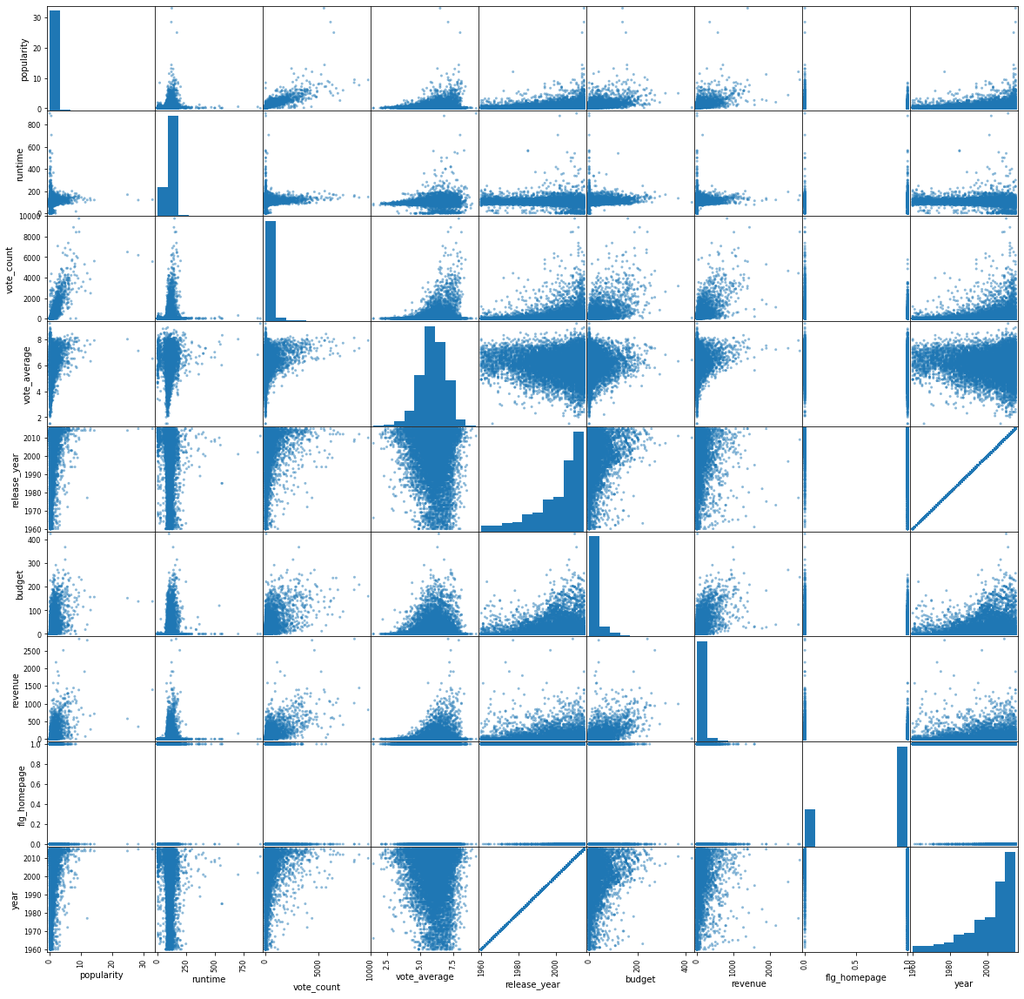

```python
#Also we are going to correlate the variables as well as their distribution
pd.plotting.scatter_matrix(df,figsize=(20,20));
```

## Research Question 1: What is the most frequent genres of movie in the 21st century?

```python
#We create a copy of the dataframe with the necessary columns
df_q1=df.loc[:,["year","revenue","genres"]].copy()
df_q1.head()
```

| id | year | revenue | genres |
| --- | --- | --- | --- |
| 135397 | 2015 | 1392.445893 | Action\|Adventure\|Science Fiction\|Thriller |
| 76341 | 2015 | 348.161292 | Action\|Adventure\|Science Fiction\|Thriller |
| 262500 | 2015 | 271.619025 | Adventure\|Science Fiction\|Thriller |
| 140607 | 2015 | 1902.723130 | Action\|Adventure\|Science Fiction\|Fantasy |
| 168259 | 2015 | 1385.748801 | Action\|Crime\|Thriller |

```python
#We identify each of the genres of the movies by creating a list
list_genres = df_q1["genres"].apply(lambda x: x.split('|')).values
print(list_genres)
```

```
[list(['Action', 'Adventure', 'Science Fiction', 'Thriller'])
 list(['Action', 'Adventure', 'Science Fiction', 'Thriller'])
 list(['Adventure', 'Science Fiction', 'Thriller']) ...
 list(['Mystery', 'Comedy']) list(['Action', 'Comedy']) list(['Horror'])]
```

```python
#We create a function since there are several columns that have several values separated by |
def uniq_values(df):
    uniq_list = []  #create a blank list
    list_genres = df.apply(lambda x: x.split('|')).values

    for i in list_genres:
        for j in i:
            #print(i,j)
            if j not in uniq_list:
                uniq_list.append(j) #we will add each column value to a list
    return uniq_list
```

```python
uniq_genr=uniq_values(df_q1["genres"]) #we obtain the relation of unique genres registered in the dataframe
print(uniq_genr)
print(len(uniq_genr))
```

```
['Action', 'Adventure', 'Science Fiction', 'Thriller', 'Fantasy', 'Crime', 'Western', 'Drama', 'Family', 'Animation', 'Comedy', 'Mystery', 'Romance', 'War', 'History', 'Music', 'Horror', 'Documentary', 'TV Movie', 'Other', 'Foreign']
21
```

```python
df_ays_genr={key:[] for key in uniq_values(df_q1["genres"])}
year=sorted(df_q1["year"].unique()) #we obtain the relation of unique release years registered in the dataframe
```

```python
for y in year: #review in each year
    year_df_q1 = df_q1[df_q1['year'] == y]
    genres_i1 = list(year_df_q1['genres'])
    genres_f1 = []

    for genre in genres_i1: # for splitting every entry in y_df[genres] with separator as "|"
        for i in genre.split("|"):
            genres_f1.append(i)

    count_genres_f1=dict()
    for i in genres_f1:
        count_genres_f1[i]=count_genres_f1.get(i,0)+1

    for genre in uniq_values(df_q1["genres"]):
        if genre not in genres_f1:
            df_ays_genr[genre].append(0)
        else:
            df_ays_genr[genre].append(count_genres_f1[genre])
```

```python
new_df = pd.DataFrame(df_ays_genr,index=year)
new_df.head(5)
```

|  | Action | Adventure | Science Fiction | Thriller | Fantasy | Crime | Western | Drama | Family | Animation | ... | Mystery | Romance | War | History | Music | Horror | Documentary | TV Movie | Other | Foreign |
| --- | --- | --- | --- | --- | --- | --- | --- | --- | --- | --- | --- | --- | --- | --- | --- | --- | --- | --- | --- | --- | --- |
| 1960 | 8 | 5 | 3 | 6 | 2 | 2 | 6 | 13 | 3 | 0 | ... | 0 | 6 | 2 | 5 | 1 | 7 | 0 | 0 | 0 | 1 |
| 1961 | 7 | 6 | 4 | 0 | 2 | 2 | 3 | 16 | 5 | 1 | ... | 1 | 7 | 2 | 3 | 2 | 3 | 0 | 0 | 0 | 1 |
| 1962 | 8 | 7 | 2 | 7 | 1 | 3 | 3 | 21 | 2 | 0 | ... | 4 | 5 | 3 | 4 | 1 | 5 | 0 | 0 | 0 | 1 |
| 1963 | 4 | 7 | 2 | 10 | 2 | 4 | 2 | 13 | 3 | 1 | ... | 6 | 8 | 1 | 4 | 0 | 9 | 0 | 0 | 0 | 2 |
| 1964 | 5 | 5 | 4 | 9 | 4 | 10 | 1 | 20 | 4 | 2 | ... | 4 | 9 | 3 | 3 | 5 | 6 | 0 | 0 | 0 | 1 |

5 rows × 21 columns

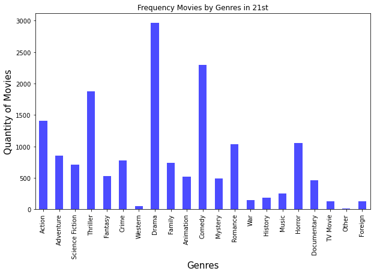

```python
#create a view with a neccesary data to show about frequency of genres of movies (21st century)
df_grap_xxi=new_df.loc[2001:,:].sum()
df_grap_xxi.plot(kind='bar',alpha=0.7,color='blue',
                 title="Frequency Movies by Genres in 21st",figsize=(10,6),fontsize=10
                )
plt.xlabel("Genres",fontsize=15)
plt.ylabel("Quantity of Movies",fontsize=15);

#source: https://pandas.pydata.org/pandas-docs/version/0.23.4/generated/pandas.DataFrame.plot.html
```

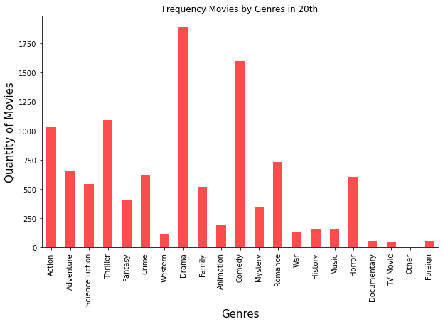

```python
#create a view with a neccesary data to show about frequency of genres of movies (20th century)
df_grap_xx=new_df.loc[:2001,:].sum()
df_grap_xx.plot(kind='bar',alpha=0.7,color='red',
                title="Frequency Movies by Genres in 20th",figsize=(10,6),fontsize=10
                )
plt.xlabel("Genres",fontsize=15)
plt.ylabel("Quantity of Movies",fontsize=15);
```

```python
#we get some values to compare the 21st century with the 20th century
(df_grap_xxi[["Drama","Comedy","Thriller"]].sum(), #quantity of movies in 21st century
df_grap_xx[["Drama","Comedy","Thriller"]].sum(),   #quantity of movies in 20th century
 df_grap_xxi[["Drama","Comedy","Thriller"]].sum()/
df_grap_xx[["Drama","Comedy","Thriller"]].sum() -1   #movie quantity variation
)
```

```
(7140, 4587, 0.5565729234793984)
```

```python
df_q2=df[df["year"]>2005].loc[:,["year","revenue","vote_average","budget","original_title","genres","director"]].copy()
df_q2.info()
```

```
<class 'pandas.core.frame.DataFrame'>
Int64Index: 5480 entries, 135397 to 15651
Data columns (total 7 columns):
 #   Column          Non-Null Count  Dtype
---  ------          --------------  -----
 0   year            5480 non-null   int64
 1   revenue         5480 non-null   float64
 2   vote_average    5480 non-null   float64
 3   budget          5480 non-null   float64
 4   original_title  5480 non-null   object
 5   genres          5480 non-null   object
 6   director        5480 non-null   object
dtypes: float64(3), int64(1), object(3)
memory usage: 342.5+ KB
```

```python
#we identify the movies that have the highest budget
df_q2['revenue'].idxmax()# movie's index that have the highest budget

#source: https://pandas.pydata.org/pandas-docs/stable/reference/api/pandas.DataFrame.idxmax.html
```

```
19995
```

```python
df_q2.groupby(["year"])['revenue'].idxmax()# movie's index that have the highest budget by year
df_max=df_q2.loc[df_q2.groupby(["year"])['revenue'].idxmax()]
df_max
```

| id | year | revenue | vote_average | budget | original_title | genres | director |
| --- | --- | --- | --- | --- | --- | --- | --- |
| 58 | 2006 | 1152.691352 | 6.8 | 216.333832 | Pirates of the Caribbean: Dead Man's Chest | Adventure\|Fantasy\|Action | Gore Verbinski |
| 285 | 2007 | 1010.653508 | 6.8 | 315.500575 | Pirates of the Caribbean: At World's End | Adventure\|Fantasy\|Action | Gore Verbinski |
| 155 | 2008 | 1014.733032 | 8.1 | 187.365527 | The Dark Knight | Drama\|Action\|Crime\|Thriller | Christopher Nolan |
| 19995 | 2009 | 2827.123750 | 7.1 | 240.886903 | Avatar | Action\|Adventure\|Fantasy\|Science Fiction | James Cameron |
| 10193 | 2010 | 1063.171911 | 7.5 | 200.000000 | Toy Story 3 | Animation\|Family\|Comedy | Lee Unkrich |
| 12445 | 2011 | 1287.183998 | 7.7 | 121.174755 | Harry Potter and the Deathly Hallows: Part 2 | Adventure\|Family\|Fantasy | David Yates |
| 24428 | 2012 | 1443.191435 | 7.3 | 208.943742 | The Avengers | Science Fiction\|Action\|Adventure | Joss Whedon |
| 109445 | 2013 | 1192.711491 | 7.5 | 140.405003 | Frozen | Animation\|Adventure\|Family | Chris Buck\|Jennifer Lee |
| 122917 | 2014 | 879.752289 | 7.1 | 230.272763 | The Hobbit: The Battle of the Five Armies | Adventure\|Fantasy | Peter Jackson |
| 140607 | 2015 | 1902.723130 | 7.5 | 183.999919 | Star Wars: The Force Awakens | Action\|Adventure\|Science Fiction\|Fantasy | J.J. Abrams |

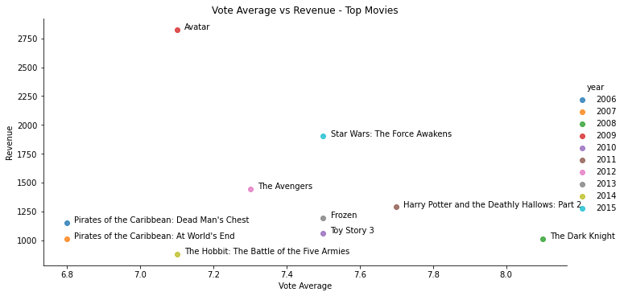

```python
#scatter plot of movies with the highest budge
sns.lmplot(x='vote_average',y='revenue',data=df_max[df_max["year"]>2005],hue='year',aspect =2,legend_out=True)
plt.title('Vote Average vs Revenue - Top Movies')
plt.xlabel('Vote Average')
plt.ylabel('Revenue')

def label_point(x, y, val, ax):
    a = pd.concat({'x': x, 'y': y, 'val': val}, axis=1)
    for i, point in a.iterrows():
        ax.text(point['x']+.02, point['y'], str(point['val']))


label_point(df_max.vote_average, df_max.revenue, df_max.original_title, plt.gca());

#source: https://stackoverflow.com/questions/15910019/annotate-data-points-while-plotting-from-pandas-dataframe
```

```python
#Indentify the genres of those movies
genres_i1 = list(df_max['genres'])
genres_f1 = []

for genre in genres_i1: # for splitting every entry in y_df[genres] with separator as "|"
    for i in genre.split("|"):
        genres_f1.append(i)

count_genres_f1=dict()
for i in genres_f1:
    count_genres_f1[i]=count_genres_f1.get(i,0)+1

count_genres_f1
```

```
{'Adventure': 8,
 'Fantasy': 6,
 'Action': 6,
 'Drama': 1,
 'Crime': 1,
 'Thriller': 1,
 'Science Fiction': 3,
 'Animation': 2,
 'Family': 3,
 'Comedy': 1}
```

```python
#we compare the highest budget movies with the total universe
df_max.describe(),df.loc[:,["year","revenue","vote_average","budget","original_title","genres","director"]].describe(),
```

```
(             year      revenue  vote_average      budget
 count    10.00000    10.000000     10.000000   10.000000
 mean   2010.50000  1377.393590      7.340000  204.488302
 std       3.02765   585.676955      0.406065   54.010815
 min    2006.00000   879.752289      6.800000  121.174755
 25%    2008.25000  1026.842752      7.100000  184.841321
 50%    2010.50000  1172.701421      7.400000  204.471871
 75%    2012.75000  1404.189576      7.500000  226.788030
 max    2015.00000  2827.123750      8.100000  315.500575,
                year       revenue  vote_average        budget
 count  10865.000000  10865.000000  10865.000000  10865.000000
 mean    2001.321859     51.369002      5.975012     17.549894
 std       12.813260    144.638333      0.935138     34.307527
 min     1960.000000      0.000000      1.500000      0.000000
 25%     1995.000000      0.000000      5.400000      0.000000
 50%     2006.000000      0.000000      6.000000      0.000000
 75%     2011.000000     33.701729      6.600000     20.853251
 max     2015.000000   2827.123750      9.200000    425.000000)
```

### Research Question 3: Which actors participated in more films in each of the genres?

```python
#To start we select a genre, in this case Drama, to get an idea of how to turn it into a function
df_q3=df[df["genres"].str.contains("Drama")]
df_q3["genres"].value_counts()
```

```
Drama                                             712
Drama|Romance                                     289
Comedy|Drama                                      280
Comedy|Drama|Romance                              222
Drama|Thriller                                    138
                                                 ...
Comedy|Drama|Crime|Thriller                         1
Drama|Animation|Family|Comedy|Fantasy               1
Drama|Thriller|Science Fiction|Romance|Foreign      1
Drama|Horror|Action|Thriller                        1
Drama|Mystery|Thriller|Romance                      1
Name: genres, Length: 894, dtype: int64
```

We count how many times an actor appears in each genre, and then select the one that appears the most times

```python
cast_i1 = list(df_q3['cast'])
cast_f1 = []

for cast_v in cast_i1: # for splitting every entry in df_q3[cast] with separator as "|"
    for i in cast_v.split("|"):
        cast_f1.append(i)

count_cast_f1=dict()
for i in cast_f1:
    count_cast_f1[i]=count_cast_f1.get(i,0)+1

#select the most hight value
df_cast=pd.DataFrame(count_cast_f1.values(),index=count_cast_f1.keys(),columns=["num_movies"])

#return actor´s name and how many appearances he has
df_cast["num_movies"].idxmax(),df_cast.loc[df_cast["num_movies"].idxmax()][0]
```

```
('Robert De Niro', 42)
```

```python
#we create the function with the structure above
def actor_max_movies_genres (df,genres):
    df_q3=df[df.genres.str.contains(genres)]
    cast_i1 = list(df_q3['cast'])
    cast_f1 = []

    for cast_v in cast_i1: # for splitting every entry in y_df[genres] with separator as "|"
        for i in cast_v.split("|"):
            cast_f1.append(i)

    count_cast_f1=dict()
    for i in cast_f1:
        count_cast_f1[i]=count_cast_f1.get(i,0)+1

    df_cast=pd.DataFrame(count_cast_f1.values(),index=count_cast_f1.keys(),columns=["num_movies"])
    return (df_cast["num_movies"].idxmax(),df_cast.loc[df_cast["num_movies"].idxmax()][0])

#example
actor_max_movies_genres(df,"Action")
```

```
('Jean-Claude Van Damme', 39)
```

```python
df_q3=df_q3.query("cast not in ('Other')") #eliminate default value

uniq_genr=uniq_values(df_q3["genres"]) #identify unique values of genres
```

```python
top_cast_genres=[]
for i in uniq_genr:
    top_cast_genres.append([i,actor_max_movies_genres(df_q3,i)[0],actor_max_movies_genres(df_q3,i)[1]])

sorted(top_cast_genres)
```

```
[['Action', 'Samuel L. Jackson', 16],
 ['Adventure', 'Richard Harris', 7],
 ['Animation', 'Dom DeLuise', 3],
 ['Comedy', 'Robin Williams', 14],
 ['Crime', 'Samuel L. Jackson', 17],
 ['Documentary', 'Robert Hetrick', 1],
 ['Drama', 'Robert De Niro', 42],
 ['Family', 'Harry Connick Jr.', 4],
 ['Fantasy', 'Kristen Stewart', 5],
 ['Foreign', 'Akshay Kumar', 4],
 ['History', 'Anthony Hopkins', 6],
 ['Horror', 'Anthony Hopkins', 5],
 ['Music', 'Zac Efron', 4],
 ['Mystery', 'Samuel L. Jackson', 9],
 ['Romance', 'Richard Gere', 15],
 ['Science Fiction', 'Jeff Bridges', 5],
 ['TV Movie', 'Heather Graham', 3],
 ['Thriller', 'Samuel L. Jackson', 17],
 ['War', 'Clint Eastwood', 5],
 ['Western', 'John Wayne', 6]]
```

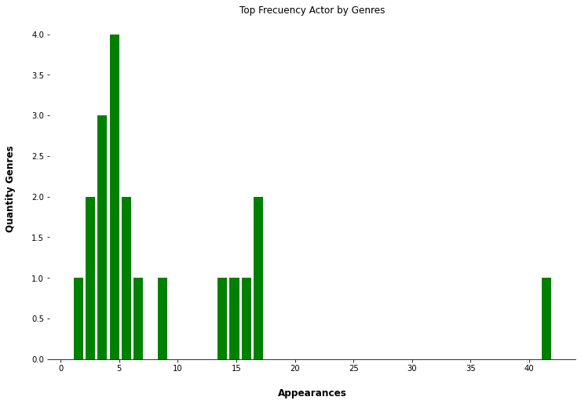

```python
pd_cast_num=pd.DataFrame(top_cast_genres,columns=["genres","cast","num_films"])

ax = pd_cast_num.hist(column='num_films', bins=40, grid=False, figsize=(12,8), color='green', zorder=2, rwidth=0.8)

ax = ax[0]
for x in ax:
    # Despine
    x.spines['right'].set_visible(False)
    x.spines['top'].set_visible(False)
    x.spines['left'].set_visible(False)

    x.set_title("Top Frecuency Actor by Genres")
    x.set_xlabel("Appearances", labelpad=20, weight='bold', size=12)
    x.set_ylabel("Quantity Genres", labelpad=20, weight='bold', size=12)

#source: https://stackoverflow.com/questions/54475071/monkey-patching-pandas-and-matplotlib-to-remove-spines-for-df-plot
#source: https://matplotlib.org/api/axes_api.html#axis-labels-title-and-legend
```

```python
pd_cast_num.describe()
```

|  | num_films |
| --- | --- |
| count | 20.000000 |
| mean | 9.400000 |
| std | 9.236085 |
| min | 1.000000 |
| 25% | 4.000000 |
| 50% | 5.500000 |
| 75% | 14.250000 |
| max | 42.000000 |

## Conclusions

> **Tip**: Finally, summarize your findings and the results that have been performed. Make sure that you are clear with regards to the limitations of your exploration. If you haven't done any statistical tests, do not imply any statistical conclusions. And make sure you avoid implying causation from correlation!

> **Tip**: Once you are satisfied with your work here, check over your report to make sure that it is satisfies all the areas of the rubric (found on the project submission page at the end of the lesson). You should also probably remove all of the "Tips" like this one so that the presentation is as polished as possible.

**Research Question 1** The most frequent genres of movies in the 21st century are Drama, Comedy and Thriller. If we do the same analysis in the 20th century, the genres with the highest number of movies are the same categories, however in the 21st century 55.6% more movies have been made of those genres.

## Submitting your Project

> Before you submit your project, you need to create a .html or .pdf version of this notebook in the workspace here. To do that, run the code cell below. If it worked correctly, you should get a return code of 0, and you should see the generated .html file in the workspace directory (click on the orange Jupyter icon in the upper left).

> Alternatively, you can download this report as .html via the **File** > **Download as** submenu, and then manually upload it into the workspace directory by clicking on the orange Jupyter icon in the upper left, then using the Upload button.

> Once you've done this, you can submit your project by clicking on the "Submit Project" button in the lower right here. This will create and submit a zip file with this .ipynb doc and the .html or .pdf version you created. Congratulations!

```python
from subprocess import call
call(['python', '-m', 'nbconvert', 'Investigate_a_Dataset.ipynb'])
```

```
0
```